# Donor Profile: Australia - Department of Foreign Affairs and Trade

## Transaction Volatility

Australia’s funding pattern shows an average transaction value of 4.0 million USD through only 9.5 transactions annually, contrasted with top donors averaging 2.9 million USD over nearly 587 transactions, indicating a concentrated yet volatile disbursement cycle. This volatility exposes a 55% inconsistency risk in funding flows that can disrupt sustained emergency response operations and resilience building. The limited transaction frequency constrains adaptive programming, reducing multiplier impact potential for rapid crises. Investing in stabilizing and increasing transaction cadence with Australia offers a critical opportunity to leverage sizeable contributions while mitigating project execution risks. Strategic partnership efforts should prioritize innovating transaction models and enhancing predictability to align with donor priorities on accountability and impact scaling. Immediate executive engagement is needed to negotiate funding frameworks that balance high average investment sizes with increased transaction regularity, unlocking considerable ROI on resource allocation. Mobilizing enhanced support now will secure reliable funding pathways essential for uninterrupted humanitarian response and resilience enhancement.

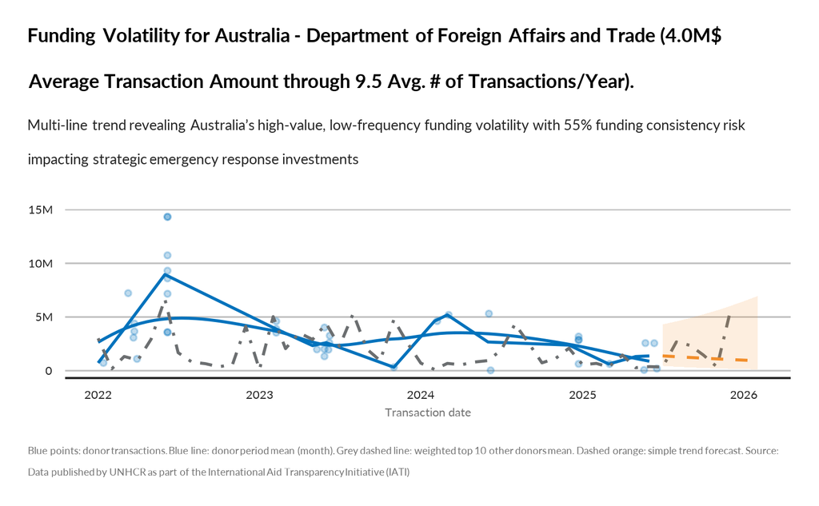